# OSTA5003 Week 1 Homework

## Three suburb housing Data

Use the filtered data from the lab

```r
smaller.dat <- read.csv("Melbourne_housing_FULL.csv") |>
  subset(Suburb %in% c("Brunswick", "Craigieburn", "Hawthorn"),
         select = c("Price", "BuildingArea", "Suburb")) |> na.omit()
head(smaller.dat)
```

```
       Price BuildingArea    Suburb
2141 1026000          108 Brunswick
2142 1802500           93 Brunswick
2143 1500000          209 Brunswick
2148 2230000          287 Brunswick
2150  410000           66 Brunswick
2151  272500           40 Brunswick
```

```r
# Fit model (a): Price ~ BuildingArea
model_a <- lm(Price ~ BuildingArea, data = smaller.dat)

# Fit model (b): Price ~ BuildingArea + Suburb
model_b <- lm(Price ~ BuildingArea + Suburb, data = smaller.dat)

# Get Adjusted R-squared
adj_r2_a <- summary(model_a)$adj.r.squared
adj_r2_b <- summary(model_b)$adj.r.squared

adj_r2_a
```

```
[1] 0.1704632
```

```r
adj_r2_b
```

```
[1] 0.4208319
```

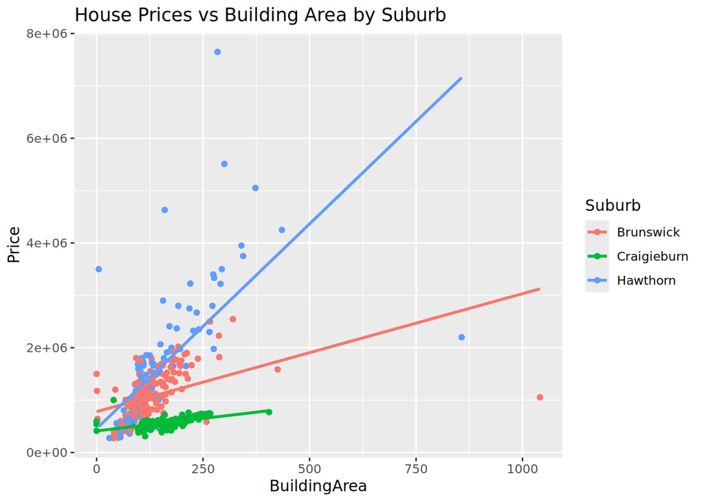

```r
library(ggplot2)

# Scatter plot colored by Suburb
ggplot(smaller.dat, aes(x = BuildingArea, y = Price, color = Suburb)) +
  geom_point() +
  geom_smooth(method = "lm", se = FALSE) +
  labs(title = "House Prices vs Building Area by Suburb")
```

```r
# Function already given
LScrit <- function(y, yhat) {
  sum((y - yhat)^2)
}

# Predict values
yhat_a <- predict(model_a)
yhat_b <- predict(model_b)

# Calculate LScrit
lscrit_a <- LScrit(smaller.dat$Price, yhat_a)
lscrit_b <- LScrit(smaller.dat$Price, yhat_b)

lscrit_a
```

```
[1] 2.216572e+14
```

```r
lscrit_b
```

```
[1] 1.540132e+14
```

```r
# Create a fake candidate model with wrong coefficients
candidate_yhat <- smaller.dat$BuildingArea * 1000 + 50000  # Arbitrary wrong model

# Calculate LScrit for candidate
lscrit_candidate <- LScrit(smaller.dat$Price, candidate_yhat)

lscrit_candidate
```

```
[1] 5.515176e+14
```

Fit the regression models to this filtered data,

1. `Price ~ BuildingArea` ($\leadsto \widehat Y = \beta_0 + \beta_1 \cdot \text{BuildingArea}$)
2. `Price ~ BuildingArea + Suburb`
1. Compare the goodness of fit of the model and explain which model seems better using the metric. (Hint: Use the adjusted R-square)
2. Visualize the data and regression fits on a scatter plot. Hint: You can visualize the `Suburb` information by colour the points differently for each suburb (using the `col` argument and integer coding if using base graphics, if using `tidyverse` you can use the `colour` argument in the aesthetic mapping)
3. Compute the LS criterion for both models. To do this you can use the code below to compute the distance of the points in the data away from the line ($y$ denote the points and $\widehat y$ denote the regression predictions from the features in the data)

```r
LScrit <- function(y, yhat) {
  sum((y - yhat)^2)
}
```

- i.e. `y` is the `Price` variable and `yhat` are the predictions from the line. Can be predicted using `predict.lm` in `R` for the least squares regression line.
4. For the simple regression, show that another candidate line has a larger `LScrit` value than the simple least squares regression line.